# ECOM90024 - Assignment 2 - Question 2

Josh Copeland

2024-04-22

```r
# Packages used for this assignment

# library(tidyverse)
# library(lubridate)
# library(forecast)
```

# Question 2

You are an analyst working for a real estate investment fund and are tasked with monitoring and forecasting house prices in the United States. The file csindex.csv contains monthly observations of the Case-Shiller U.S. National Home Price Index from January 1987 to December 2022. You are required to compute all your estimations and plots in R.

### a) Generate a plot of the data and provide a brief description of the observed time series. (1 Mark)

Chart 1 below shows a plot of the data from the Case-Shiller US National Home Price Index, which seeks to measures the price level of existing single family-homes in the US. The data provided shows this price level from January 1987 to December 2022.

There is a clear upward trend in this series over time, but there is also clear evidence of cyclical fluctuations in the data. It is unclear to what extent the curvature of this series is attributable to the trend or the incidence of cyclical fluctuations in the series over time. It’s also possible that some of the shorter-term fluctuations (that seem to increase over time) could be attributable to seasonal patterns in the data. Testing and accounting for both of these deterministic patterns in the data is required to isolate the cyclical fluctuations.

The clearest indicator of cyclical fluctuations in this data is the significant acceleration of growth in the series in the mid-2000s (and the decline which followed in 2007/2008), likely driven by the unsustainable household credit conditions that culminated in the US’ sub-prime mortgage crisis that kicked off the Global Financial Crisis.

```r
data <- read_csv("csindex.csv") %>%
  select(date = DATE, price_level = CSUSHPISA) %>%
  mutate(date = dmy(date)) %>%
  na.omit()
```

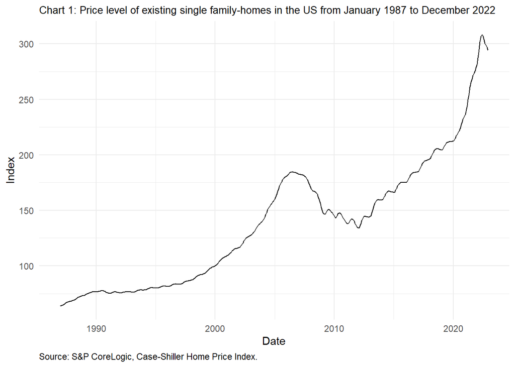

```r
ggplot(data, aes(x = date, y = price_level)) +
  geom_line() +
  ggtitle("Chart 1: Price level of existing single family-homes in the US from January 1987 to December 2022") +
  labs( x = "Date",
        y = "Index",
        caption = "Source: S&P CoreLogic, Case-Shiller Home Price Index.") +
  theme(plot.title = element_text(size = 10),
        plot.caption = element_text(hjust = 0))
```

### b) Using the data from January 1987 to December 2018, identify and estimate an appropriate time series model using the steps outlined in Lecture 6. Make sure to report all relevant estimation results, plots, statistical tests and information criteria that you are relying on in determining your preferred model. (2 Marks)

Each step of the general approach for estimating a time series model is available below in order.

- Specify and estimate deterministic components
  - As noted in part (a), there seems to be some long-run upwards trend to the series. Therefore, I have evaluated the fit of a collection of deterministic trend models below (linear, quadratic and exponential). Their fits have been illustrated in Chart 2. I evaluate the linear model as optimum model for decomposing the trend component of this time series, because it has the lowest AIC/BIC of the models evaluated (as seen in the model_selection_criteria table below). By taking the residuals of this model we can observe the detrended series, as seen in Chart 3.
  - Using the detrended series we are able to determine if there is any deterministic seasonality in the data: I conclude this is not the case. This is done by generating a collection of dummy variables for each month of the year, and then regressing the detrended series on these dummy variables (as seen in the summary of the seasonal_model object). None of the estimated ceofficients are statistically different from zero. Moreover, they are jointly equal to zero according to the reported overall F-statistic, which has a p-value greater than 0.05. Therefore, we can conclude that the seasonal means are not statistically different from zero and we do not have to de-season our data. This means the residuals of the linear model, or the detrended series, also represents the cyclical component of our time series.

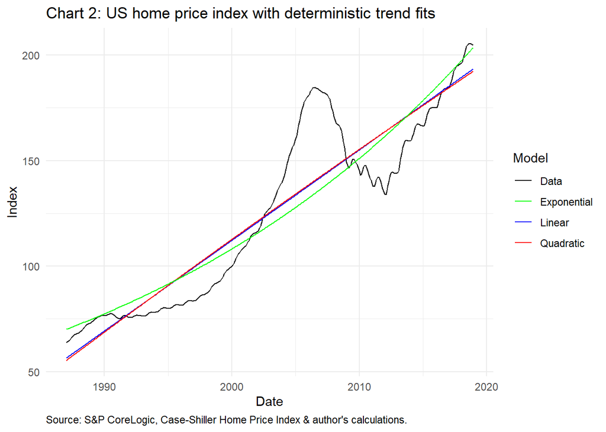

```r
################################################################################
################### SPECIFYING DETERMINISTIC TRENDS ############################
################################################################################

################# GENERATING TREND COMPONENT OF TIME SERIES ####################

data <- data %>%
  filter(date < as.Date("2019-01-01"))

data <- data %>%
  mutate(

    time = seq(1,length(data$price_level)),
    time_square = time^2,
    hits_log = log(price_level)

  )


# ESTIMATING MODELS


# Linear model

price_model_linear <- lm(price_level ~ time, data = data)

#Quadratic model

price_model_quadratic <- lm(price_level ~ time + time_square, data = data)

#Exponential model

price_model_exponential_descaled <- nls(price_level ~ a*exp(b*time), start = list(a=8000, b = 0.01), data = data)


# EXTRACTING MODEL FITS

data <- data %>%
  mutate(

    linear_model = predict(price_model_linear),

    quadratic_model = predict(price_model_quadratic),

    exponential_model = predict(price_model_exponential_descaled)

  )


ggplot(data, aes(x = date)) +
  geom_line(aes(y = price_level, colour = "Data")) +
  geom_line(aes(y = linear_model, colour = "Linear")) +
  geom_line(aes(y = quadratic_model, colour = "Quadratic")) +
  geom_line(aes(y = exponential_model, colour = "Exponential")) +
  scale_color_manual(values = c("Data"= "black" ,"Linear" = "blue", "Quadratic" = "red", "Exponential" = "green")) +
  labs(colour = "Model") +
  labs(x = "Date", y = "Index", caption = "Source: S&P CoreLogic, Case-Shiller Home Price Index & author's calculations.") +
  ggtitle("Chart 2: US home price index with deterministic trend fits") +
    theme(plot.caption = element_text(hjust = 0))
```

```r
# COMPARING MODEL OUTPUTS

model_list <- list(price_model_linear, price_model_quadratic, price_model_exponential_descaled)

model_names <- c("price_model_linear", "price_model_quadratic", "price_model_exponential_descaled")

extract_criteria <- function(model, model_name) {
  summary_data <- summary(model)
  aic <- AIC(model)
  bic <- BIC(model)
  return(data.frame(Model = model_name, AIC = aic, BIC = bic))
}

model_selection_criteria <- map2_df(model_list, model_names, extract_criteria) %>%
  arrange(AIC)

print(model_selection_criteria)
```

```
##                              Model      AIC      BIC
## 1               price_model_linear 3245.817 3257.669
## 2            price_model_quadratic 3247.453 3263.255
## 3 price_model_exponential_descaled 3297.471 3309.322
```

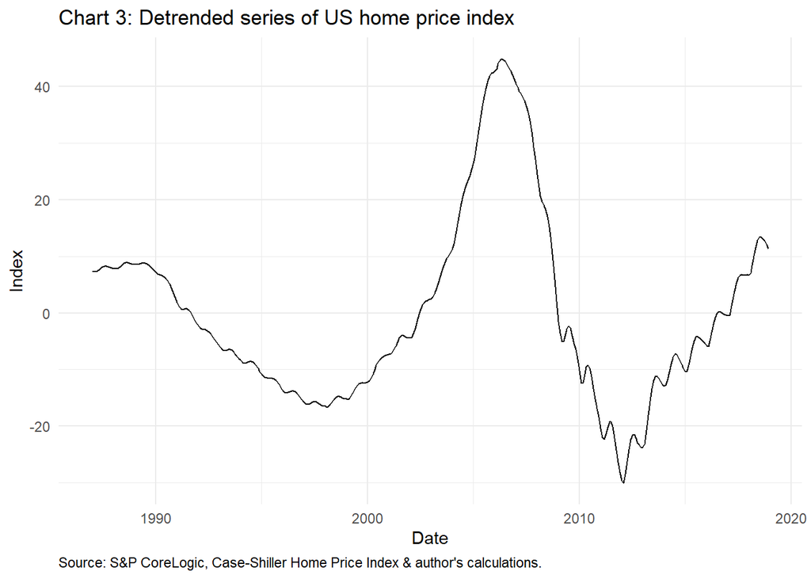

```r
# Linear model returns the lowest AIC/BIC. Therefore use this as the trend series.

# Need to generate the detrended series to test for seasonal effects

data <- data %>%
  mutate(

    detrended = resid(price_model_linear)

  )

ggplot(data, aes(x = date)) +
  geom_line(aes(y = detrended)) +
  labs(x = "Date", y = "Index", caption = "Source: S&P CoreLogic, Case-Shiller Home Price Index & author's calculations.") +
  ggtitle("Chart 3: Detrended series of US home price index") +
  theme(plot.caption = element_text(hjust = 0))
```

```r
################# GENERATING SEASONAL COMPONENT OF TIME SERIES #################



data <- data %>%
  mutate(month = month(date)) %>%
  mutate(

    jan_dummy = case_when(month == 1 ~ 1, TRUE ~ 0),
    feb_dummy = case_when(month == 2 ~ 1, TRUE ~ 0),
    mar_dummy = case_when(month == 3 ~ 1, TRUE ~ 0),
    apr_dummy = case_when(month == 4 ~ 1, TRUE ~ 0),
    may_dummy = case_when(month == 5 ~ 1, TRUE ~ 0),
    jun_dummy = case_when(month == 6 ~ 1, TRUE ~ 0),
    jul_dummy = case_when(month == 7 ~ 1, TRUE ~ 0),
    aug_dummy = case_when(month == 8 ~ 1, TRUE ~ 0),
    sep_dummy = case_when(month == 9 ~ 1, TRUE ~ 0),
    oct_dummy = case_when(month == 10 ~ 1, TRUE ~ 0),
    nov_dummy = case_when(month == 11~ 1, TRUE ~ 0),
    dec_dummy = case_when(month == 12 ~ 1, TRUE ~ 0),


  )

seasonal_model <- lm(detrended ~ 0 + jan_dummy + feb_dummy + mar_dummy +
                       apr_dummy + may_dummy + jun_dummy +
                       jul_dummy + aug_dummy + sep_dummy +
                       oct_dummy + nov_dummy + dec_dummy,
                     data = data)


summary(seasonal_model)
```

```
##
## Call:
## lm(formula = detrended ~ 0 + jan_dummy + feb_dummy + mar_dummy +
##     apr_dummy + may_dummy + jun_dummy + jul_dummy + aug_dummy +
##     sep_dummy + oct_dummy + nov_dummy + dec_dummy, data = data)
##
## Residuals:
##     Min      1Q  Median      3Q     Max
## -28.578 -11.730  -4.288   7.911  45.200
##
## Coefficients:
##           Estimate Std. Error t value Pr(>|t|)
## jan_dummy  -1.2419     2.9473  -0.421    0.674
## feb_dummy  -1.5055     2.9473  -0.511    0.610
## mar_dummy  -1.1474     2.9473  -0.389    0.697
## apr_dummy  -0.4607     2.9473  -0.156    0.876
## may_dummy   0.2968     2.9473   0.101    0.920
## jun_dummy   0.9454     2.9473   0.321    0.749
## jul_dummy   1.2736     2.9473   0.432    0.666
## aug_dummy   1.2584     2.9473   0.427    0.670
## sep_dummy   0.9063     2.9473   0.308    0.759
## oct_dummy   0.4243     2.9473   0.144    0.886
## nov_dummy  -0.1021     2.9473  -0.035    0.972
## dec_dummy  -0.6472     2.9473  -0.220    0.826
##
## Residual standard error: 16.67 on 372 degrees of freedom
## Multiple R-squared:  0.003379,   Adjusted R-squared:  -0.02877
## F-statistic: 0.1051 on 12 and 372 DF,  p-value: 0.9999
```

- Generate the residuals
  - Because we do not need to deseasonalise our data, the detrended series is sufficient for isolating the cyclical component of the time series. The final components that constitute this time series (observed, trend and cyclical) are avalable in the data_decomposed dataframe.
    - Before continuing, it is important to establish that this cyclical series is not white noise, such that it demonstrates some level of dependence which can be usefully modelled through an ARMA process. After conducting the portmanteau Box-Pierce and Ljung-Box tests, we can verify this cyclical data is not white noise. This is because both tests return a very small p-value, rejecting the null hypothesis of both tests that there is no autocorrelation in the time series. This implies dependence in this time series, suitable for ARMA modelling.

```r
################################################################################
######################### GENERATING THE RESIDUALS #############################
################################################################################



data_decomposed <- data %>%
  select(date, price_level, trend = linear_model, cyclical = detrended)


# CONFIRMING THE CYCLICAL DATA IS NOT WHITE NOISE

m = ceiling((sqrt(length(data_decomposed$price_level))))

Box.test(data_decomposed$cyclical, lag = m, type = "Box-Pierce")
```

```
##
##  Box-Pierce test
##
## data:  data_decomposed$cyclical
## X-squared = 5893, df = 20, p-value < 2.2e-16
```

```r
Box.test(data_decomposed$cyclical, lag = m, type = "Ljung-Box")
```

```
##
##  Box-Ljung test
##
## data:  data_decomposed$cyclical
## X-squared = 6071.2, df = 20, p-value < 2.2e-16
```

- Generate the ACF and PACF of the residuals to get a sense of their dependence structure.
  - Chart 4 shows the sample autocorrelation function (ACF) for the cyclical US home price index series for the 1st to 20th lag. It shows that these autocorrelations are decaying gradually over these lags.
  - Chart 5 shows the sample partial autocorrelation function (PACF) for the cyclical US home price index from the 1st to 20th lag. These lags cut off initially at lag 3, but then become significant again from lags 9 to 13.
  - Based off this information, this tells us that when choosing an ARMA(p,q) model, we should search for a model with a p parameter up to order 13. We also need a minimum value of 1 because we need to account for dependency in our model (i.e. we know this isn’t a white noise process). Given its not advisable to have a very large number of MA terms in a model, we will only search for a model with a q parameter up to order 4.

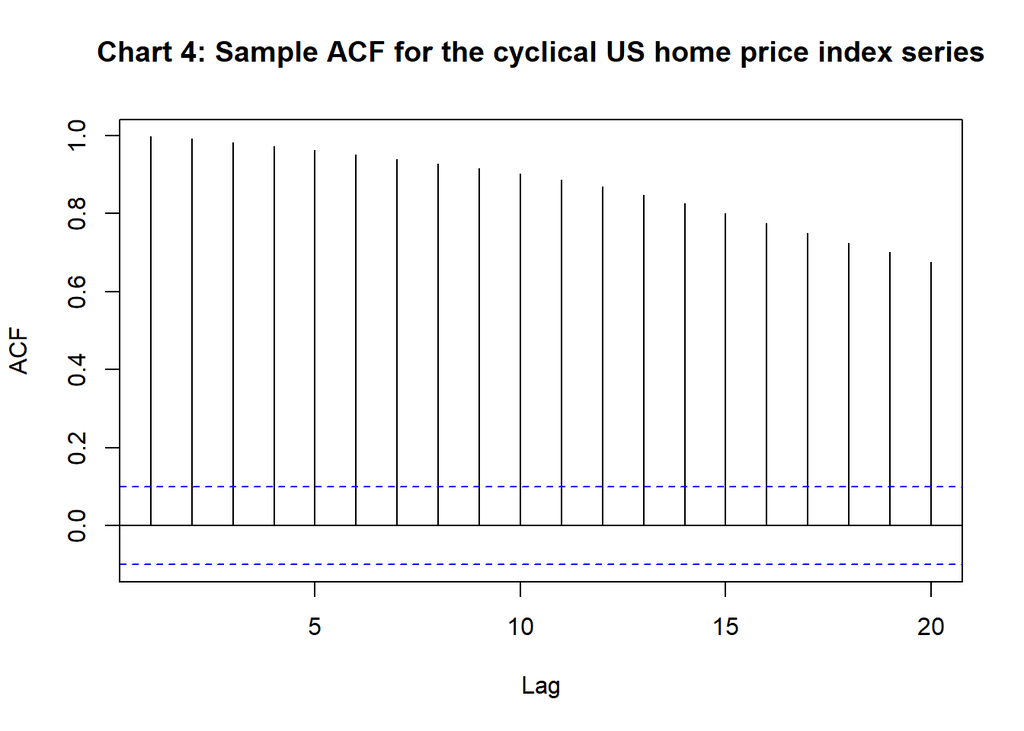

```r
#################################################################################
############ ANALYSING DEPENDENCE STRUCTURE OF CYCLICAL DATA ####################
################################################################################


# GENERATING ACF AND PACF

acf_cyclical <- acf(data_decomposed$cyclical, plot = FALSE)
pacf_cyclical <- pacf(data_decomposed$cyclical, plot = FALSE)

plot(acf_cyclical[1:20], main = "Chart 4: Sample ACF for the cyclical US home price index series")
```